# Schéma de regulations croisées

Gustavo Magaña López

02/04/2021

```r
library(tidyverse)
library(deSolve)
library(rootSolve)
library(foreach)
library(gridExtra)
```

On considère un système dans lequel **chacune des deux composantes $X$ et $Y$ régule la synthèse de l’autre**, en ayant toujours le même type d’action, soit activatrice, soit inhibitrice. $X$ et $Y$ sont par ailleurs soumis à un processus de dégradation correspondant à une réaction du premier ordre.

Cette dynamique est modélisée par les équations différentielles $f$, $g$ suivantes :

$$f(X, Y) = \frac{dX}{dt} = v_{in x} - v_{out x}
= k_{inx}\left( 1 + \alpha\frac{Y^n}{1 + Y^n}\right) - k_{outx} X$$

$$g(X, Y) = \frac{dY}{dt} = v_{in y} - v_{out y}
= k_{in y}\left( 1 + \beta\frac{X^n}{1 + X^n}\right) - k_{out y} Y$$

Selon les signes des paramètres $\alpha$ et $\beta$…

Quelques fonctions ont été créées afin de faciliter l’analyse en minimisant la redondance d’instructions. L’intégralité du code peut être consultée [**ici**](https://github.com/gmagannaDevelop/Modelisation/blob/main/notebooks/TP6_MAGANA_LOPEZ.Rmd).

Pour simplifier la notation on écrira $\frac{\partial f}{\partial x} \rightarrow \partial_x f$ quand on devra mettre les dérivées dans le texte.

# Question 1

Établir les équations explicites des isoclines nulles du système sous la forme $X = f(Y)$ et $Y = f(X)$.

## voie analytique

**R** : Par définition, les isoclines nulles s’obtiennent lorsque les dérivées s’annullent. En imposant $\partial_t X = 0$ et $\partial_t Y = 0$, nous obtenons avec une manipulation algébrique minimale, pour $X$ :

$$X = f(Y) = \frac{k_{inx}}{k_{outx}}
\left(\ 1 + \alpha\frac{Y^n}{1 + Y^n} \right)$$

et pour $Y$ :

$$Y = f(X) = \frac{k_{iny}}{k_{outy}}
\left(\ 1 + \beta\frac{X^n}{1 + X^n} \right)$$

## visualisation

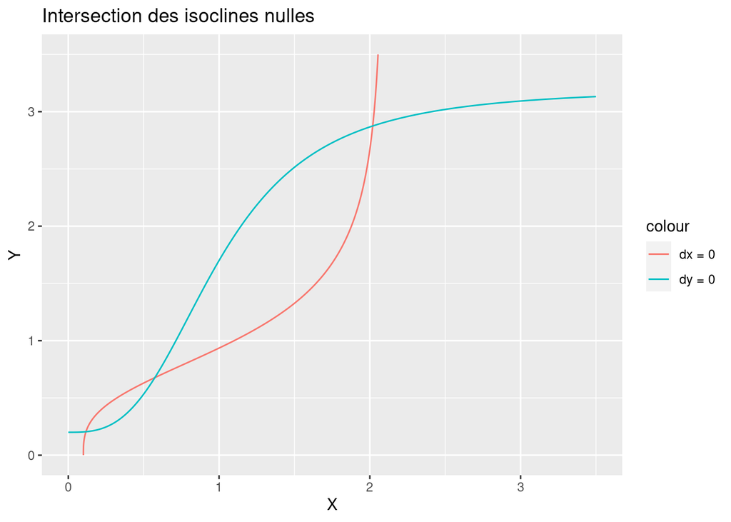

```r
params <- c(kinx = 0.1, kiny = 0.2, koutx = 1, kouty = 1, n = 3, a = 20, b = 15)

x_from_params <- function(params) {
    with(as.list(c(params)), {
        .x <- function(Y) {
            (kinx/koutx) * (1 + a * Y^n/(1 + Y^n))
        }
        return(.x)
    })
}

y_from_params <- function(params) {
    with(as.list(c(params)), {
        .y <- function(X) {
            (kiny/kouty) * (1 + b * X^n/(1 + X^n))
        }
        return(.y)
    })
}

X <- x_from_params(params)
Y <- y_from_params(params)

grille.xy <- seq(from = 0, to = 3.5, length.out = 300)

plan.phase <- data.frame(t = grille.xy, dx = X(grille.xy), dy = Y(grille.xy)) %>%
    tibble()

plan.phase %>% ggplot() + geom_line(aes(x = dx, y = t, colour = "dx = 0")) + geom_line(aes(x = t,
    y = dy, colour = "dy = 0")) + labs(x = "X", y = "Y", title = "Intersection des isoclines nulles")
```

# Question 2

## manipulation algébrique

À partir des équations différentielles, calculer par recherche numérique puis tracer l’isocline nulle $\partial_t X = 0$ ($X = f(Y)$) et l’isocline nulle $\partial_t Y = 0$ ($Y = f(X)$).

En partant de $g(X, Y) = \partial_t Y = 0$, nous obtenons une expression pour $X = f(Y)$, qui est la suivante :

$$x = \sqrt[^n]{\frac{\lambda y - 1}{\beta - \lambda y + 1}} \;\;\;
| \;\; \lambda = \frac{k_{outy}}{k_{iny}}$$

en faisant la substitution de l’expression précédente dans $f(X, Y) = \partial_t X = 0$ nous obtenons :

$$0 = k_{inx}\left( 1 + \alpha\frac{Y^n}{1 + Y^n}\right) - k_{outx} \left( \sqrt[^n]{\frac{\lambda y - 1}{\beta - \lambda y + 1}}\right)$$

## recherche numérique

```r
x_of_y_from_params <- function(params) {
    with(as.list(c(params)), {
        x <- function(Y) {
            ((lamb * Y - 1)/(b - lamb * Y + 1))^(1/n)
        }
        return(x)
    })
}

explicit_y_from_params <- function(params) {
    with(as.list(c(params)), {
        .f <- function(Y) {
            lamb <- kouty/kiny
            res <- kinx * (1 + a * (Y^n/(1 + Y))) - koutx * ((lamb * Y - 1)/(b -
                lamb * Y + 1))^(1/n)
            return(res)
        }
    })
}

y_stars <- explicit_y_from_params(params)
x_of_y <- x_of_y_from_params(params)

uniroot.all(y_stars, lower = 0, upper = 3.5)
```

```
## [1] 0.7706482
```

Je ne sais pas pourquoi `uniroot.all()` ne trouve pas toutes les racines.

# Question 3

Calculer les coordonnées du(des) état(s) stationnaire(s) du système par analyse des modes normaux.

## rappel analyse de la matrice jacobienne

La matrice dite **Jacobienne** d’un système $n \times n$ est définie comme suit :

$$\mathbf{J} = \left(\frac{\partial f_i}{\partial x_j}\right)_{i,j}
\;\; | \;\; i, j \in \lbrace 1, .. n\rbrace$$

Elle définit un système différentiel linéaire intégrable analytiquement si on l’approxime par un développement en série de Taylor, limité à l’ordre un.

$$\frac{d}{dt}\left[ x_i^\star + \Delta x_1\right] =
f_i^\star + \left[
\left(\frac{\partial f_i}{\partial x_1}\right)_{x^\star} \Delta x_1 +
\left(\frac{\partial f_i}{\partial x_2}\right)_{x^\star} \Delta x_2
\right]$$

Ce système admet une solution particulière de la forme suivante :

$$\Delta x_i(t) = A_{i, 1} e^{r_1 t} + A_{i, 2} e^{r_2 t}$$

Où $r_1$ et $r_2$ sont les racines de l’équation caractéristique associée :

$$r^2 - (\mathbf{j}_{1,1}+\mathbf{j}_{2,2})r \; +
(\mathbf{j}_{1,1}\mathbf{j}_{1,1} - \mathbf{j}_{1,2}\mathbf{j}_{2,1}) = 0$$
Avec les quantités caractéristiques suivantes :

- $Tr$ Trace de la jacobienne : $Tr = \mathbf{j}_{1,1} + \mathbf{j}_{2,2} = r_1 + r_2$
- $\Delta$ Déterminant de la jacobienne : $\Delta = \mathbf{j}_{1,1} \times \mathbf{j}_{2,2} = r_1 \times r_2$
- $\delta$ Discriminant de l’équation caractéristique $\delta = (Tr)^2 - 4\Delta$

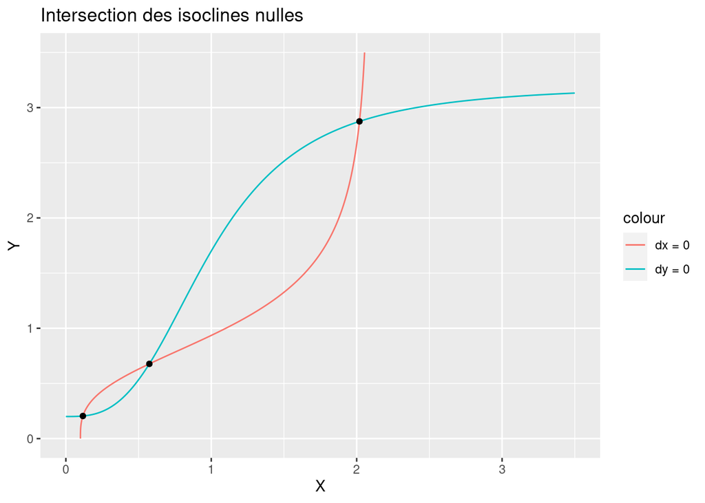

```r
derivee.solver <- function(t, condinit, parametres) {
    #' Function to be pased to deSolve::ode()
    with(as.list(c(condinit, parametres)), {
        dx <- kinx * (1 + a * Y^n/(1 + Y^n)) - koutx * X
        dy <- kiny * (1 + b * X^n/(1 + X^n)) - kouty * Y
        return(list(c(dx, dy)))
    })
}
# valeurs de X et Y détérminés à l'œil à partir de la visualisation des isoclines
# nulles (formulés explicitement X = f(y) et Y = f(X))
x.star1 <- stode(y = c(X = 0, Y = 0), parms = params, func = derivee.solver)
x.star2 <- stode(y = c(X = 0.5, Y = 0.5), parms = params, func = derivee.solver)
x.star3 <- stode(y = c(X = 2, Y = 3), parms = params, func = derivee.solver)


plan.phase %>% ggplot() + geom_line(aes(x = dx, y = t, colour = "dx = 0")) + geom_line(aes(x = t,
    y = dy, colour = "dy = 0")) + add_point(x.star1) + add_point(x.star2) + add_point(x.star3) +
    labs(x = "X", y = "Y", title = "Intersection des isoclines nulles")
```

# Question 4

Stabilité des états stationnaires.

```r
etats.stationnaires <- list(x.star1, x.star2, x.star3)
classif.es <- etats.stationnaires %>% resume_st_points(params, derivee.solver)
```

| X.star | Y.star | trace | determinant | discriminant | Type |
| --- | --- | --- | --- | --- | --- |
| 0.1170338 | 0.2048013 | -2 | 0.9696009 | 0.1215965 | Noeud stable |
| 0.5740771 | 0.6772861 | -2 | -2.3602936 | 13.4411745 | Point de selle |
| 2.0192433 | 2.8750840 | -2 | 0.9651928 | 0.1392289 | Noeud stable |

# Question 5

```r
temps <- seq(0, 4, length.out = 500)

sol.q5.1 <- create_trajectory(y = c(X = 1, Y = 1), times = temps, parms = params,
    func = derivee.solver)

sol.q5.2 <- create_trajectory(y = c(X = 2, Y = 0.5), times = temps, parms = params,
    func = derivee.solver)
```

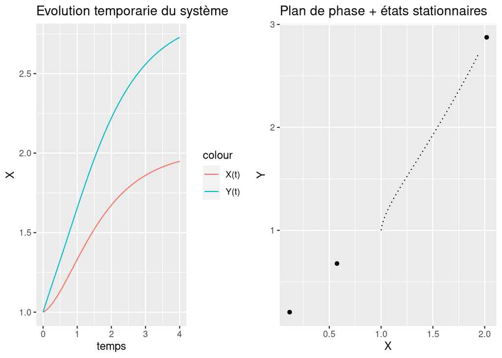

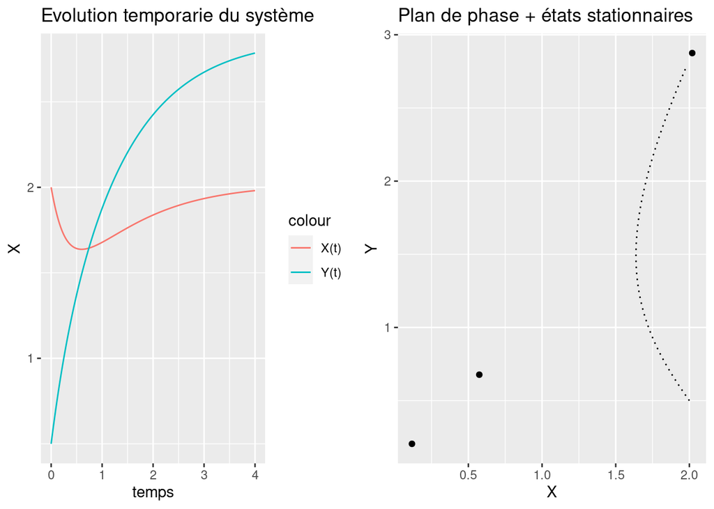

# Question 6

## évaluation numérique et commentaire

```r
# nous changeons kouty <- 1.2 et a <- 30
params <- c(kinx = 0.1, kiny = 0.2, koutx = 1, kouty = 1.2, n = 3, a = 30, b = 15)

x.star1 <- stode(y = c(X = 0, Y = 0), parms = params, func = derivee.solver)
x.star2 <- stode(y = c(X = 0.5, Y = 0.5), parms = params, func = derivee.solver)
x.star3 <- stode(y = c(X = 2, Y = 3), parms = params, func = derivee.solver)

etats.stationnaires <- list(x.star1, x.star2, x.star3)
classif.es <- etats.stationnaires %>% resume_st_points(params, derivee.solver)
```

| X.star | Y.star | trace | determinant | discriminant | Type |
| --- | --- | --- | --- | --- | --- |
| 0.1147809 | 0.1704415 | -2.2 | 1.169396 | 0.1624143 | Noeud stable |
| 0.5804313 | 0.5755747 | -2.2 | -3.261350 | 17.8853985 | Point de selle |
| 2.9333540 | 2.5713938 | -2.2 | 1.179348 | 0.1226082 | Noeud stable |

Étant données les valeurs des différents indicateurs du caractère d’un état stationnaire (trace $Tr$, déterminant $\Delta$ et discriminant de l’équation caractéristique $\delta$), on constate qu’il s’agit de nœuds et points de selle, pour lesquelles l’équation caractéristique n’aura pas de racines complexes sinon réelles. (voir **Question 3**).

Donc ces points ne peuvent pas engendrer des oscillations, qui se produisent lorsque $r_1, r_2 \in \mathbb{C}$. De l’équation d’Euler :

$$e^{\theta i} = cos(\theta) \;+\; i\;sin(\theta)$$
une racine complexe transformerait chaque terme d’une solution particulière comme suit :

$$A_{j}e^{r_j t} = A_j e^{\mathbb{R}(r_j)}\left[cos(\mathbb{I}(r_j)) + i\;
sin(\mathbb{I}(r_j)) \right]
\;\;\forall r_j \in \mathbb{C}$$

Ce qui donnerait les oscillations.

## essai analytique

Pour le montrer analytiquement, on doit calculer la jacobienne analyser le discriminant de l’équation caractéristique :

$$J =
\begin{pmatrix}
\partial_x f & \partial_y f \\
\partial_x g & \partial_y g
\end{pmatrix} =
\begin{pmatrix}
-k_{outx} & k_{inx}\alpha\left(\frac{n y^{n-1}}{(1 + y^n)^2}\right) \\
k_{iny}\beta\left(\frac{n x^{n-1}}{(1 + x^n)^2}\right) & -k_{outy}
\end{pmatrix}$$

La trace de la jacobienne $Tr(\mathbf{J})$ :

$$Tr(\mathbf{J}) = -k_{outx} - k_{outy} = -(k_{outx} + k_{outy})$$

Le déterminant de la jacobienne $\Delta\mathbf{J}$

$$\Delta\mathbf{J} = k_{outx}k_{outy} - k_{inx}k_{iny}\alpha\beta
\frac{n^2 X^{n-1} Y^{n-1}}{(1+X^n)^2(1+Y^n)^2}$$

si l’on définit $k_{out} = k_{outx}k_{outy}$, $k_{in} = k_{inx}k_{iny}$, $\psi = \alpha\beta$, on peut réécrire le déterminant comme suit :

$$\Delta\mathbf{J} = k_{out} - k_{in}\psi
\frac{n^2 X^{n-1} Y^{n-1}}{(1+X^n)^2(1+Y^n)^2}$$

Finalement, le discriminant de l’équation caractéristique :

$$\delta = (Tr)^2 - 4\Delta = k_{outx}^2 + 2k_{out} + k_{outy}^2 -
4\left(k_{out} - k_{in}\psi
\frac{n^2 X^{n-1} Y^{n-1}}{(1+X^n)^2(1+Y^n)^2}\right)$$

$$\delta = k_{outx}^2 - 2k_{out} + k_{outy}^2
+4 k_{in}\psi
\frac{n^2 X^{n-1} Y^{n-1}}{(1+X^n)^2(1+Y^n)^2}$$

Je suppose que je devrais voir ici que le discriminant est toujours positif, cependant ceci ne m’est pas évident et je ne sais pas si une évaluation exhaustive sur valeurs de $(X,Y)$ et en changeant le signe de $\beta$ (négatif pour inhibition, positif pour activation) est la démarche à suivre.

# Question 7

Reproduisez les isoclines et quelques trajectoires des deux figures ci-dessous. Interpréter…

```r
# figure de gauche > params1, figure de droite > params2
params1 <- c(kinx = 7, kiny = 8, koutx = 1, kouty = 1, a = -0.95, b = -0.95, n = 1)
params2 <- c(kinx = 7, kiny = 8, koutx = 1, kouty = 1, a = -0.95, b = -0.95, n = 3)

p7.1 <- plot_phase_plane(params1)
p7.2 <- plot_phase_plane(params2)

temps <- seq(0, 8, length.out = 300)

tictoc::tic()
sol.q7 <- ode(y = c(X = 1, Y = 1), times = temps, parms = params1, func = derivee.solver)
sol.q7.df <- sol.q7 %>% as.data.frame() %>% tibble()
tictoc::toc()
```

```
## 0.017 sec elapsed
```

Le temps d’intégration n’est pas important pour le système étudié.

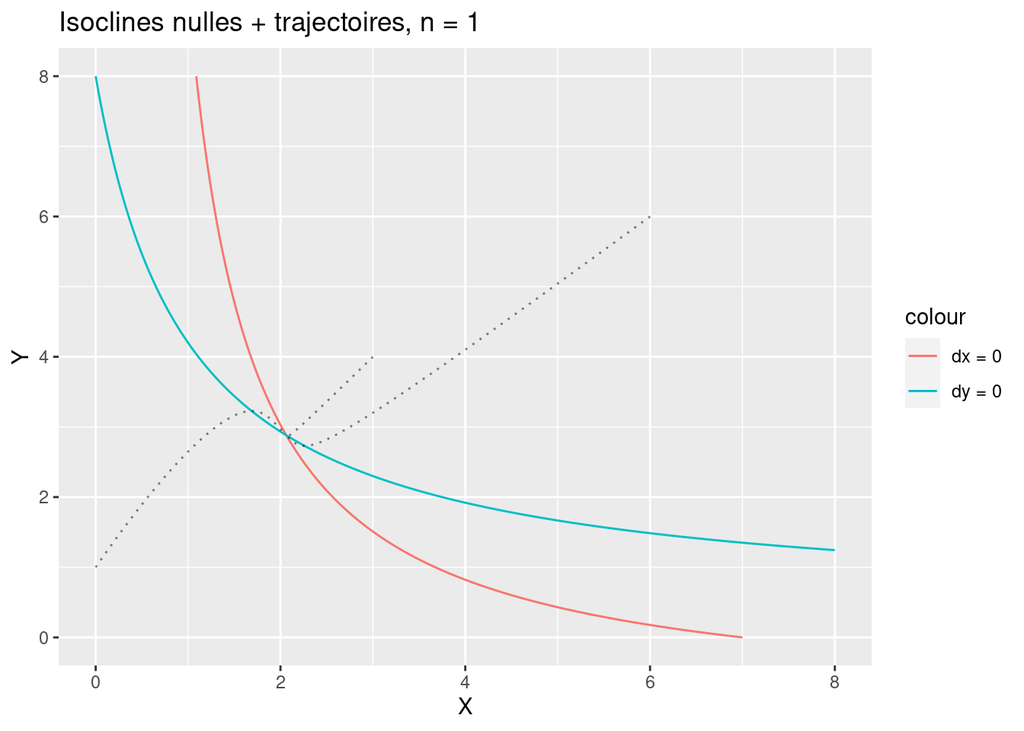

```r
traj1 <- create_trajectory(y = c(X = 0, Y = 1), times = temps, parms = params1, func = derivee.solver)
traj2 <- create_trajectory(y = c(X = 3, Y = 4), times = temps, parms = params1, func = derivee.solver)
traj3 <- create_trajectory(y = c(X = 6, Y = 6), times = temps, parms = params1, func = derivee.solver)

trajs <- list(traj1, traj2, traj3)

p7.1 %>% add_trajectories(trajs, X, Y, alpha = 0.5, title = "Isoclines nulles + trajectoires, n = 1")
```

Ici on peut voir que à partir des points initiaux $(0, 1)$, $(3, 4)$ et $(6, 6)$, les trajectoires convergent vers l’état stationnaire. D’un point de vue biologique, les concentrations de deux substances soumisses à un schéma de régulation croisé évolueront jusqu’aux concentrations respectives qui permettraient la fonction biologique optimale.

## reproduction des trajectoires

```r
initial.grid <- seq(0, 8, length.out = 6)
n.initial <- length(initial.grid)
# listes de conditions initiales et solutions
condinit.ls <- vector("list", n.initial^2)
solutions1.ls <- vector("list", n.initial^2)
solutions2.ls <- vector("list", n.initial^2)

# boucle pour créer n.initial^2 conds. init
for (i in 0:(n.initial - 1)) {
    for (j in 1:n.initial) {
        # toutes les combinaisons désirées :
        condinit.ls[[i * n.initial + j]] <- c(X = initial.grid[i + 1], Y = initial.grid[j])
        # solutions pour n = 1
        solutions1.ls[[i * n.initial + j]] <- create_trajectory(y = condinit.ls[[i *
            n.initial + j]], times = temps, parms = params1, func = derivee.solver)
        # solutions pour n = 3
        solutions2.ls[[i * n.initial + j]] <- create_trajectory(y = condinit.ls[[i *
            n.initial + j]], times = temps, parms = params2, func = derivee.solver)
    }
}
```

## modes normaux pour n=1

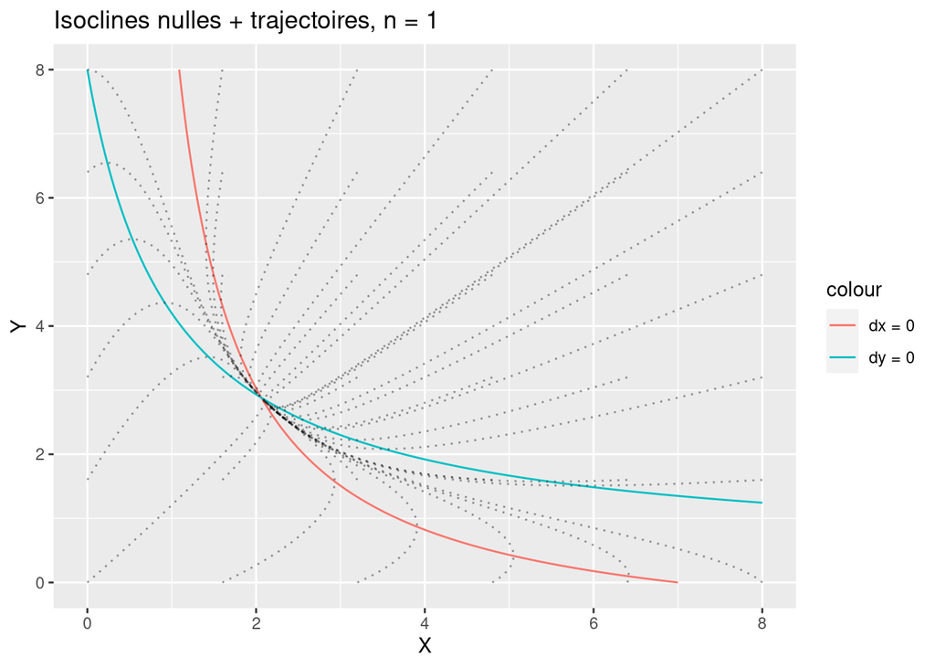

| X.star | Y.star | trace | determinant | discriminant | Type |
| --- | --- | --- | --- | --- | --- |
| 2.063585 | 2.880753 | -2 | 0.6424446 | 1.430222 | Noeud stable |

```r
x.star1 <- stode(y = c(X = 2, Y = 3), parms = params1, func = derivee.solver)
etats.stationnaires <- list(x.star1)
classif.es <- etats.stationnaires %>% resume_st_points(params1, derivee.solver)
p7.1 %>% add_trajectories(solutions1.ls, X, Y, alpha = 0.4, title = "Isoclines nulles + trajectoires, n = 1")
```

## modes normaux pour n=3

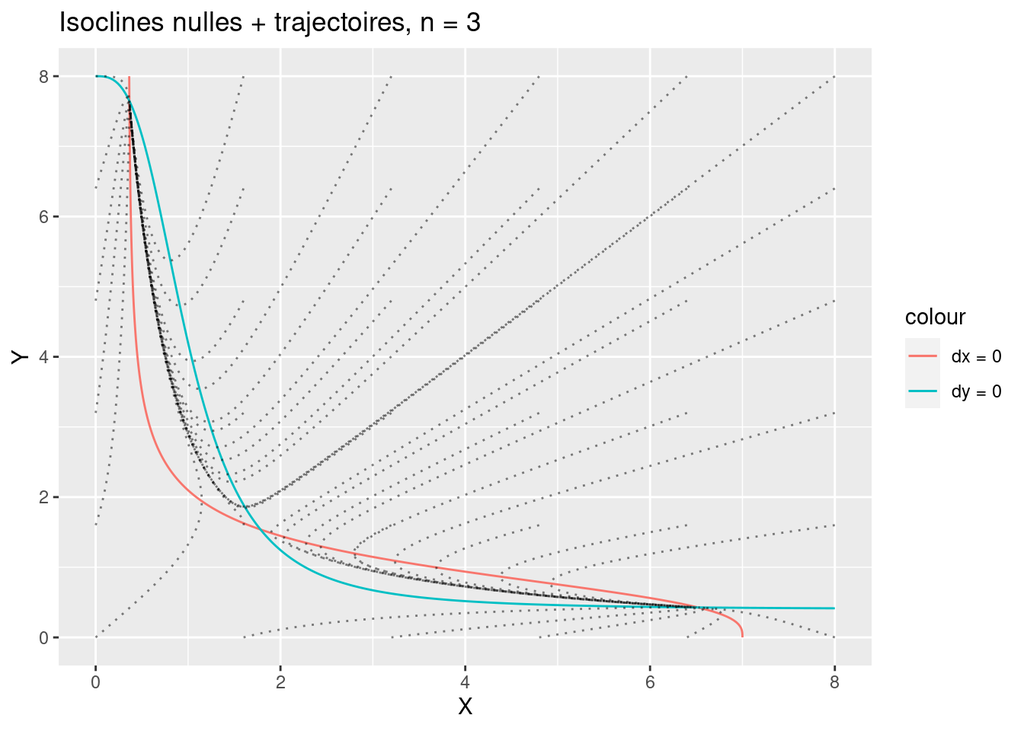

| X.star | Y.star | trace | determinant | discriminant | Type |
| --- | --- | --- | --- | --- | --- |
| 0.3648321 | 7.6480351 | -2 | 0.9839772 | 0.0640911 | Noeud stable |
| 1.7841576 | 1.5378331 | -2 | -2.5697920 | 14.2791678 | Point de selle |
| 6.5186014 | 0.4273392 | -2 | 0.9606988 | 0.1572046 | Noeud stable |

```r
x.star1 <- stode(y = c(X = 0.5, Y = 7), parms = params2, func = derivee.solver)
x.star2 <- stode(y = c(X = 1.5, Y = 1.5), parms = params2, func = derivee.solver)
x.star3 <- stode(y = c(X = 6.5, Y = 1), parms = params2, func = derivee.solver)
etats.stationnaires <- list(x.star1, x.star2, x.star3)
classif.es <- etats.stationnaires %>% resume_st_points(params2, derivee.solver)
p7.2 %>% add_trajectories(solutions2.ls, X, Y, alpha = 0.5, title = "Isoclines nulles + trajectoires, n = 3")
```

Les trajectoires convergent vers les nœuds stables, comme on l’avait observé précédemment. Les trajectoires atteignent leurs maxima ou minima quand elles s’intersectent avec les isoclines nulles correspondantes. C’est-à-dire : Pour une trajectoire quelconque, la valeur maximale/minimale de $X$ est atteinte à l’intersection avec l’isocline nulle $\partial_t X = 0$, idem pour $Y$.